# R-Ladies La Paz ’ - Sesión 1

### 3.3 Mapeos estéticos

Asignar colores a la variable clase

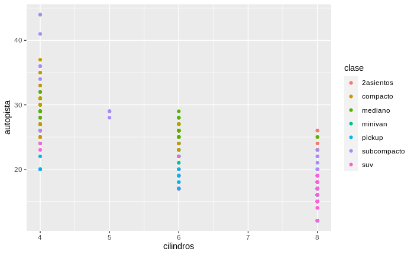

```r
ggplot(data = millas) +
  geom_point(mapping = aes(x = cilindros, y = autopista, color = clase))
```

Asignar tamaño a la variable clase

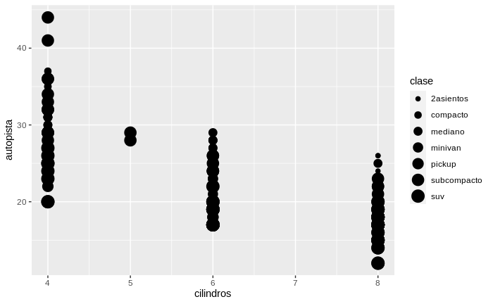

```r
ggplot(data = millas) +
  geom_point(mapping = aes (x = cilindros, y = autopista, size = clase))
```

Estética alpha para controlar la transparencia de los puntos

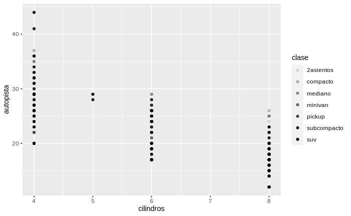

```r
ggplot(data = millas) +
  geom_point(mapping = aes(x = cilindros, y= autopista, alpha = clase))
```

Estética shape para controlar la forma

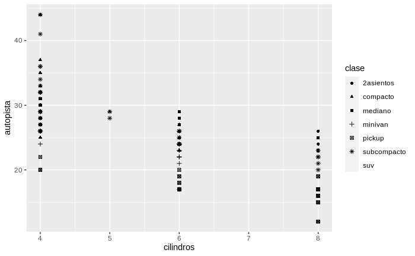

```r
ggplot(data = millas) +
  geom_point(mapping = aes(x = cilindros, y = autopista, shape = clase))
```

Fijar las propiedades estéticas del geom manualmente

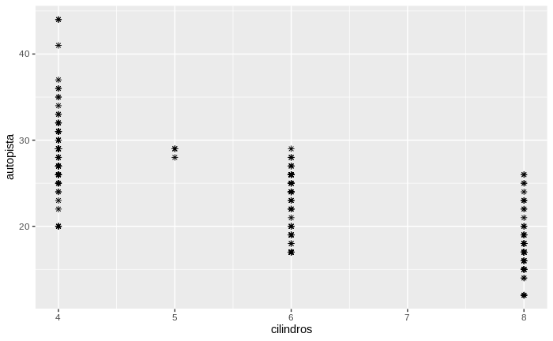

```r
ggplot(data = millas) +
  geom_point(mapping = aes(x = cilindros, y = autopista), shape = "asterisk")
```

### 3.3.1 Ejercicios

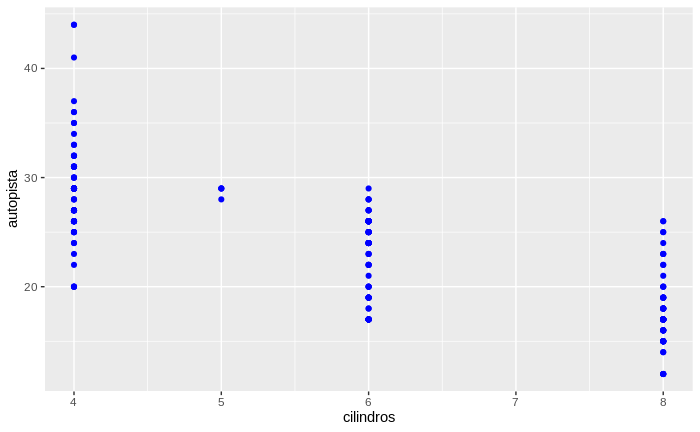

```r
ggplot(data = millas) +
  geom_point(mapping = aes(x = cilindros, y = autopista), color = "blue")
```

2. ¿Qué variables en millas son categóricas? ¿Qué variables son continuas? (Sugerencia: escribe ?millas para leer la documentación de ayuda para este conjunto de datos). ¿Cómo puedes ver esta información cuando ejecutas millas?

```r
?millas
```

```r
glimpse(millas)
```

```
Observations: 234
Variables: 11
$ fabricante  <chr> "audi", "audi", "audi", "audi", "audi", "audi", "audi", "audi", "audi", "audi", "audi", "…
$ modelo      <chr> "a4", "a4", "a4", "a4", "a4", "a4", "a4", "a4 quattro", "a4 quattro", "a4 quattro", "a4 q…
$ motor       <dbl> 1.8, 1.8, 2.0, 2.0, 2.8, 2.8, 3.1, 1.8, 1.8, 2.0, 2.0, 2.8, 2.8, 3.1, 3.1, 2.8, 3.1, 4.2,…
$ anio        <int> 1999, 1999, 2008, 2008, 1999, 1999, 2008, 1999, 1999, 2008, 2008, 1999, 1999, 2008, 2008,…
$ cilindros   <int> 4, 4, 4, 4, 6, 6, 6, 4, 4, 4, 4, 6, 6, 6, 6, 6, 6, 8, 8, 8, 8, 8, 8, 8, 8, 8, 8, 8, 8, 8,…
$ transmision <chr> "auto(l5)", "manual(m5)", "manual(m6)", "auto(av)", "auto(l5)", "manual(m5)", "auto(av)",…
$ traccion    <chr> "d", "d", "d", "d", "d", "d", "d", "4", "4", "4", "4", "4", "4", "4", "4", "4", "4", "4",…
$ ciudad      <int> 18, 21, 20, 21, 16, 18, 18, 18, 16, 20, 19, 15, 17, 17, 15, 15, 17, 16, 14, 11, 14, 13, 1…
$ autopista   <int> 29, 29, 31, 30, 26, 26, 27, 26, 25, 28, 27, 25, 25, 25, 25, 24, 25, 23, 20, 15, 20, 17, 1…
$ combustible <chr> "p", "p", "p", "p", "p", "p", "p", "p", "p", "p", "p", "p", "p", "p", "p", "p", "p", "p",…
$ clase       <chr> "compacto", "compacto", "compacto", "compacto", "compacto", "compacto", "compacto", "comp…
```

3. Asigna una variable continua a color, size, y shape. ¿Cómo se comportan estas estéticas de manera diferente para variables categóricas y variables continuas?

Variable continua con color

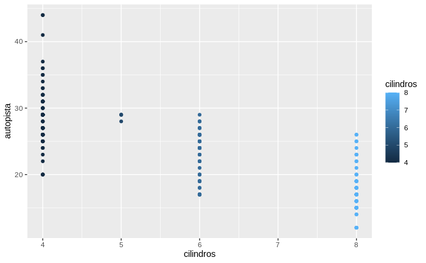

```r
ggplot(data = millas) +
  geom_point(mapping = aes(x= cilindros, y = autopista, color = cilindros))
```

Variable continua con tamaño

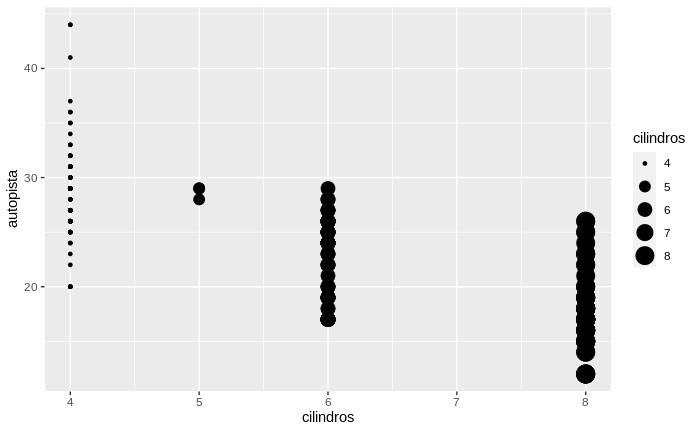

```r
ggplot(data = millas) +
  geom_point(mapping = aes(x= cilindros, y = autopista, size = cilindros))
```

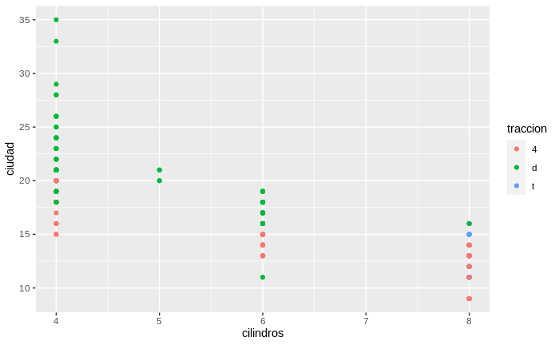

```r
ggplot(data = millas) +
  geom_point(mapping = aes(x= cilindros, y = ciudad, color = traccion))
```

Variable categórica con forma:

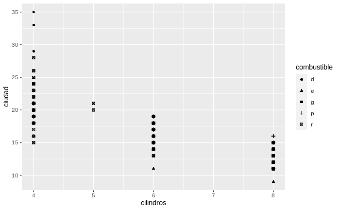

```r
ggplot(data = millas) +
  geom_point(mapping = aes(x= cilindros, y = ciudad, shape = combustible))
```

4. ¿Qué ocurre si asignas o mapeas la misma variable a múltiples estéticas?

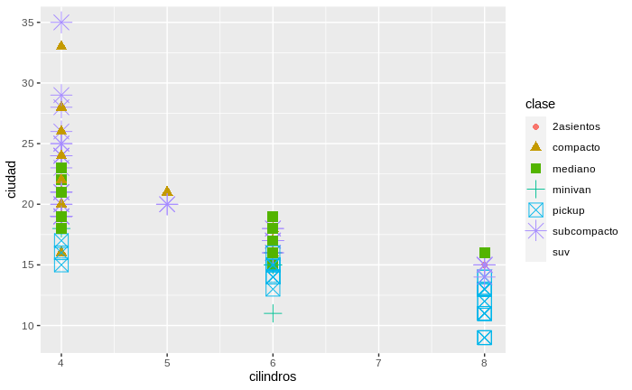

```r
ggplot(data = millas) +
  geom_point(mapping = aes(x= cilindros, y = ciudad, color = clase, size = clase,  shape = clase))
```

Resp. Mapea todas las estéticas dadas.

5. ¿Qué hace la estética stroke? ¿Con qué formas trabaja? (Sugerencia: consultar ?geom_point)

```r
?geom_point
```

Probando con stroke: modifica el tamaño del pincel o trazo

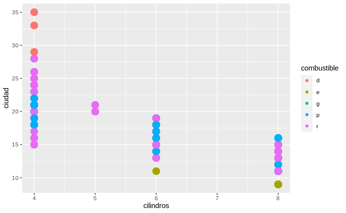

```r
ggplot(data = millas) +
  geom_point(mapping = aes(x= cilindros, y = ciudad, color = combustible, stroke = 3))
```

6. ¿Qué ocurre si se asigna o mapea una estética a algo diferente del nombre de una variable, como aes(color = cilindros < 5)?

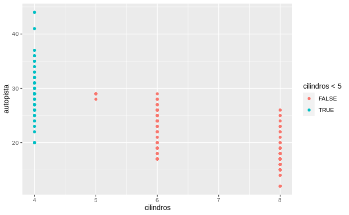

```r
ggplot(data = millas) +
  geom_point(mapping = aes(x = cilindros, y = autopista, color = cilindros < 5))
```

Resp. Cuando se compara con operadores lógicos se grafican los boleanos (True y False)

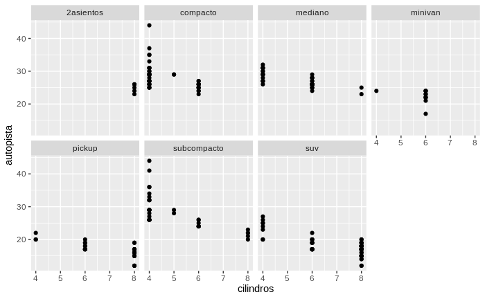

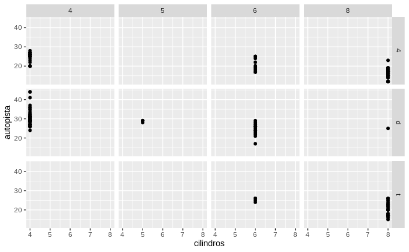

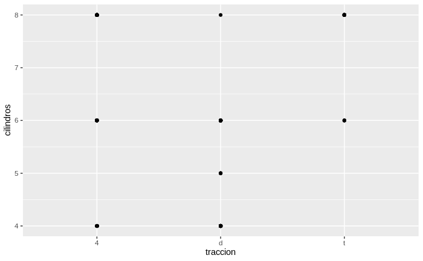

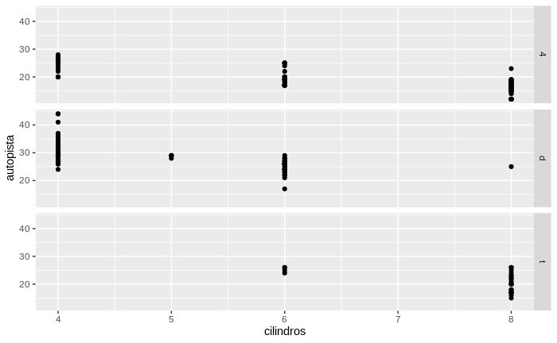

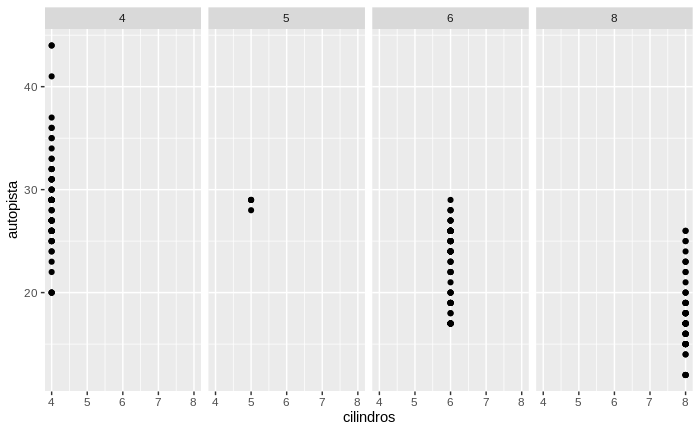

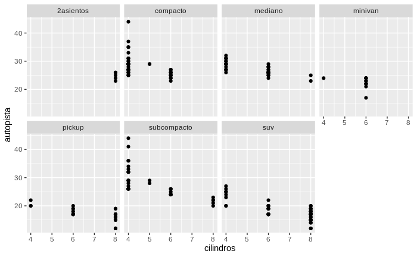

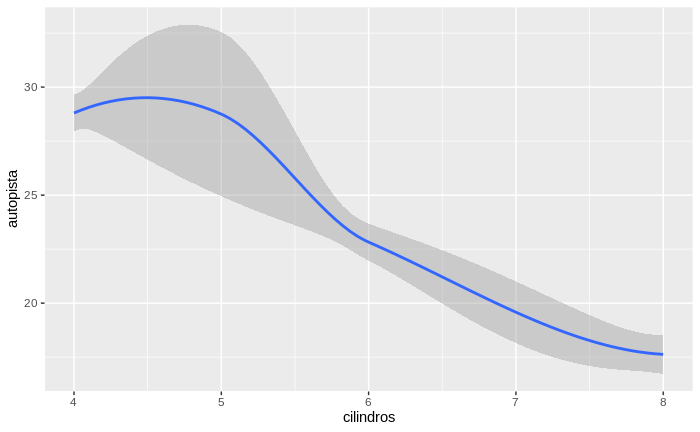

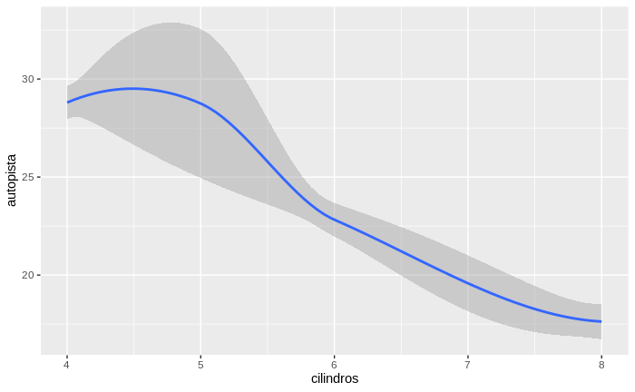

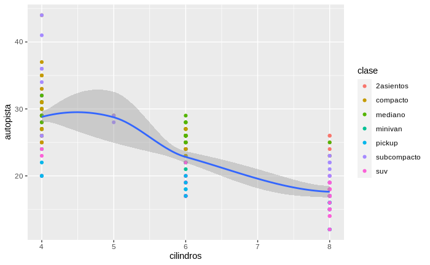

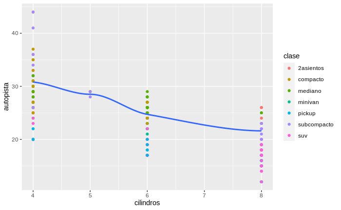

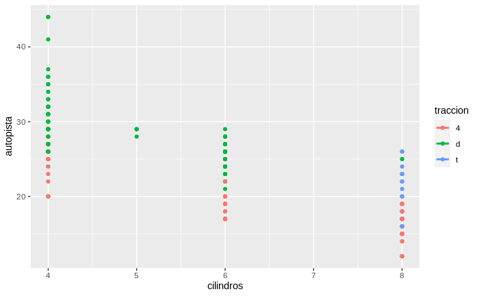

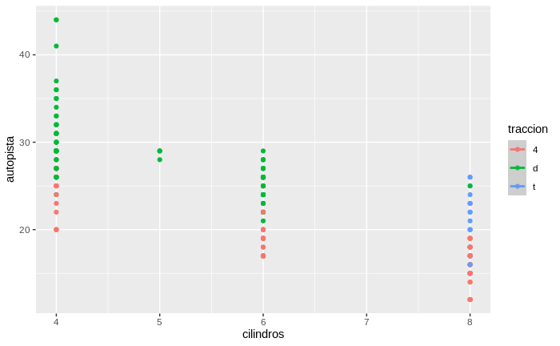

[37 more figures not shown]